# Adult_salary_pridction

```python
# importing nessary library
import numpy as np
import pandas as pd
import matplotlib.pyplot as plt
import seaborn as sns

# to split data and some scores
from sklearn.model_selection import train_test_split
from sklearn.model_selection import RandomizedSearchCV
from sklearn.model_selection import GridSearchCV
# importing all the algorithams
from sklearn.tree import DecisionTreeClassifier
from sklearn.linear_model import LogisticRegression
from sklearn.ensemble import (

                              AdaBoostClassifier,
                              GradientBoostingClassifier,
                              BaggingClassifier,
                              RandomForestClassifier,
)
from xgboost import XGBClassifier
from sklearn.model_selection import StratifiedKFold
from sklearn.model_selection import cross_val_score
# checking performance
from sklearn import metrics
from sklearn.metrics import (

                             accuracy_score,
                             precision_score,
                             recall_score,
                             f1_score,
                             confusion_matrix

)
```

```python
from google.colab import files
import io
try:
  uploaded
except:
  uploaded=files.upload()
```

```python
# reading,copying and overview
data=pd.read_csv("adult.csv")
df1=data.copy()
df1.head()
```

|  | age | workclass | fnlwgt | education | education-num | marital-status | occupation | relationship | race | sex | capital-gain | capital-loss | hours-per-week | country | salary |
| --- | --- | --- | --- | --- | --- | --- | --- | --- | --- | --- | --- | --- | --- | --- | --- |
| 0 | 39 | State-gov | 77516 | Bachelors | 13 | Never-married | Adm-clerical | Not-in-family | White | Male | 2174 | 0 | 40 | United-States | <=50K |
| 1 | 50 | Self-emp-not-inc | 83311 | Bachelors | 13 | Married-civ-spouse | Exec-managerial | Husband | White | Male | 0 | 0 | 13 | United-States | <=50K |
| 2 | 38 | Private | 215646 | HS-grad | 9 | Divorced | Handlers-cleaners | Not-in-family | White | Male | 0 | 0 | 40 | United-States | <=50K |
| 3 | 53 | Private | 234721 | 11th | 7 | Married-civ-spouse | Handlers-cleaners | Husband | Black | Male | 0 | 0 | 40 | United-States | <=50K |
| 4 | 28 | Private | 338409 | Bachelors | 13 | Married-civ-spouse | Prof-specialty | Wife | Black | Female | 0 | 0 | 40 | Cuba | <=50K |

```python
# Checking swhape of the dataframe
df1.shape
```

```
(32561, 15)
```

- There are 32561 rows and 15 columns

```python
# checking the data type of all the features of df1
df1.info()
```

```
<class 'pandas.core.frame.DataFrame'>
RangeIndex: 32561 entries, 0 to 32560
Data columns (total 15 columns):
 #   Column          Non-Null Count  Dtype
---  ------          --------------  -----
 0   age             32561 non-null  int64
 1   workclass       32561 non-null  object
 2   fnlwgt          32561 non-null  int64
 3   education       32561 non-null  object
 4   education-num   32561 non-null  int64
 5   marital-status  32561 non-null  object
 6   occupation      32561 non-null  object
 7   relationship    32561 non-null  object
 8   race            32561 non-null  object
 9   sex             32561 non-null  object
 10  capital-gain    32561 non-null  int64
 11  capital-loss    32561 non-null  int64
 12  hours-per-week  32561 non-null  int64
 13  country         32561 non-null  object
 14  salary          32561 non-null  object
dtypes: int64(6), object(9)
memory usage: 3.7+ MB
```

- Age, fnlwgt , education-num ,capital_gain,capital_loss,hours-per-week is inteager.rest of the column is object.

```python
# Checking statical summary of dataframe
df1.describe(include="all").T
```

|  | count | unique | top | freq | mean | std | min | 25% | 50% | 75% | max |
| --- | --- | --- | --- | --- | --- | --- | --- | --- | --- | --- | --- |
| age | 32561.0 | NaN | NaN | NaN | 38.581647 | 13.640433 | 17.0 | 28.0 | 37.0 | 48.0 | 90.0 |
| workclass | 32561 | 9 | Private | 22696 | NaN | NaN | NaN | NaN | NaN | NaN | NaN |
| fnlwgt | 32561.0 | NaN | NaN | NaN | 189778.366512 | 105549.977697 | 12285.0 | 117827.0 | 178356.0 | 237051.0 | 1484705.0 |
| education | 32561 | 16 | HS-grad | 10501 | NaN | NaN | NaN | NaN | NaN | NaN | NaN |
| education-num | 32561.0 | NaN | NaN | NaN | 10.080679 | 2.57272 | 1.0 | 9.0 | 10.0 | 12.0 | 16.0 |
| marital-status | 32561 | 7 | Married-civ-spouse | 14976 | NaN | NaN | NaN | NaN | NaN | NaN | NaN |
| occupation | 32561 | 15 | Prof-specialty | 4140 | NaN | NaN | NaN | NaN | NaN | NaN | NaN |
| relationship | 32561 | 6 | Husband | 13193 | NaN | NaN | NaN | NaN | NaN | NaN | NaN |
| race | 32561 | 5 | White | 27816 | NaN | NaN | NaN | NaN | NaN | NaN | NaN |
| sex | 32561 | 2 | Male | 21790 | NaN | NaN | NaN | NaN | NaN | NaN | NaN |
| capital-gain | 32561.0 | NaN | NaN | NaN | 1077.648844 | 7385.292085 | 0.0 | 0.0 | 0.0 | 0.0 | 99999.0 |
| capital-loss | 32561.0 | NaN | NaN | NaN | 87.30383 | 402.960219 | 0.0 | 0.0 | 0.0 | 0.0 | 4356.0 |
| hours-per-week | 32561.0 | NaN | NaN | NaN | 40.437456 | 12.347429 | 1.0 | 40.0 | 40.0 | 45.0 | 99.0 |
| country | 32561 | 42 | United-States | 29170 | NaN | NaN | NaN | NaN | NaN | NaN | NaN |
| salary | 32561 | 2 | <=50K | 24720 | NaN | NaN | NaN | NaN | NaN | NaN | NaN |

- min. age is 17,max. ager is 90,and average is 38.
- most of the workclass belong to private.
- most of the sex belong to male.
- most of the adults belong to united state.
- <=50k is most of the sellary

```python
# droping capital gainj,capital loss
df1=df1.drop(["capital-gain","capital-loss"],axis=1)
```

- removing capital gain and capital loss because its not contain any useful information.

```python
df1.duplicated().sum()
```

```
26
```

```python
#droping duplicated
df1=df1.drop_duplicates()
df1.duplicated().sum()
```

```
0
```

- there are no duplicates.

## EDA

```python
#selecting dtypes
num_col=df1.select_dtypes(include=np.number)
cat_col=df1.select_dtypes(include=["category","object"])
```

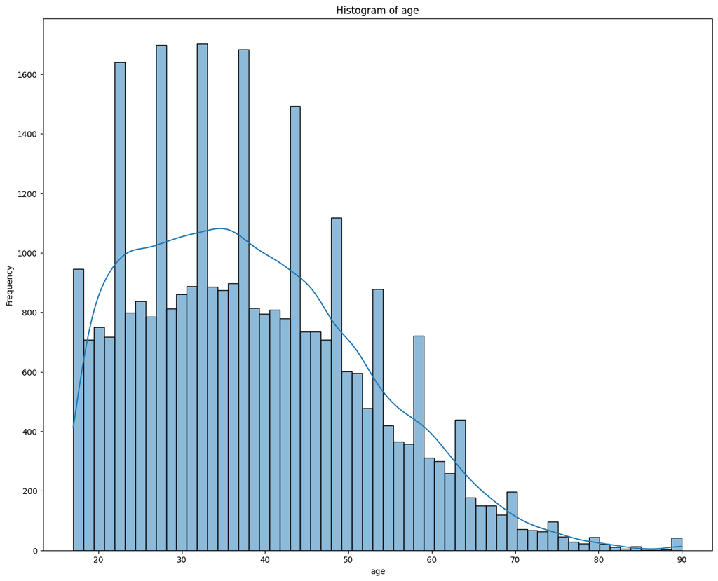

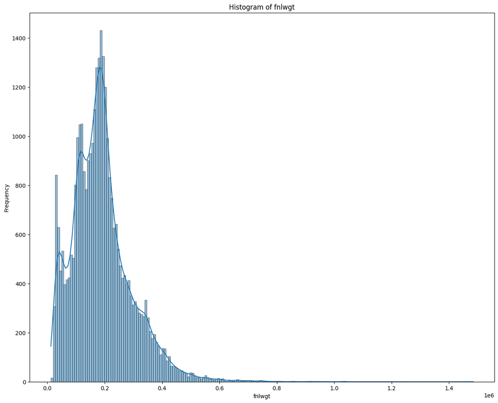

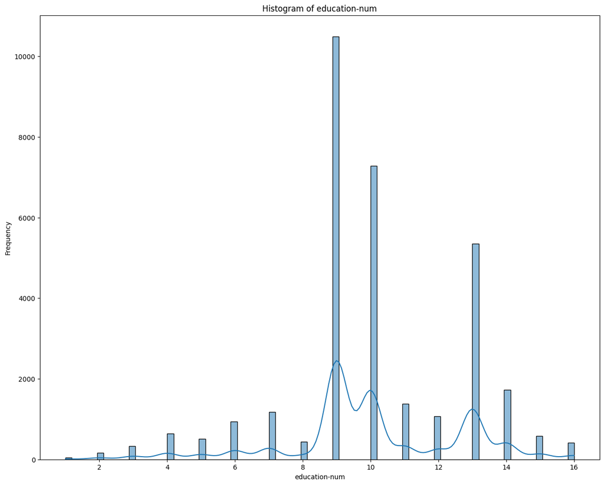

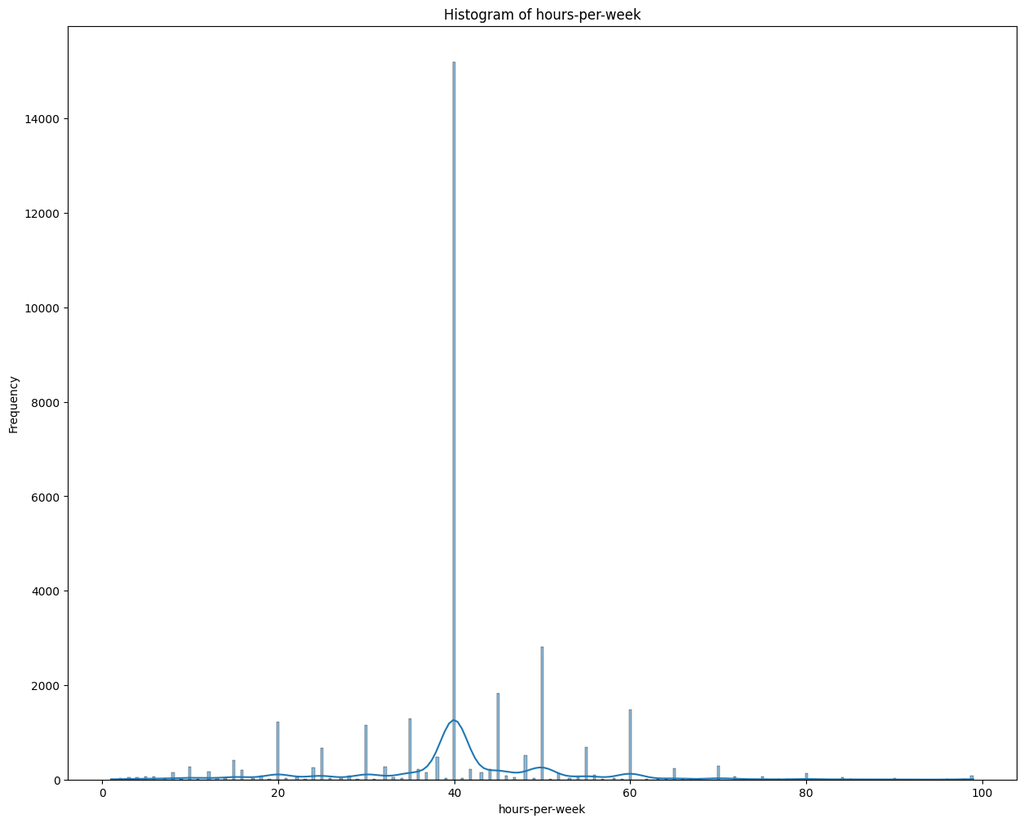

```python
for i in num_col:
    plt.figure(figsize=(15, 12))
    sns.histplot(df1[i], kde=True)
    plt.title(f'Histogram of {i}')
    plt.xlabel(i)
    plt.ylabel('Frequency')
    plt.show()
```

- 40 hr. per week is most working hour.
- there are skewed data there might be huge outliers.

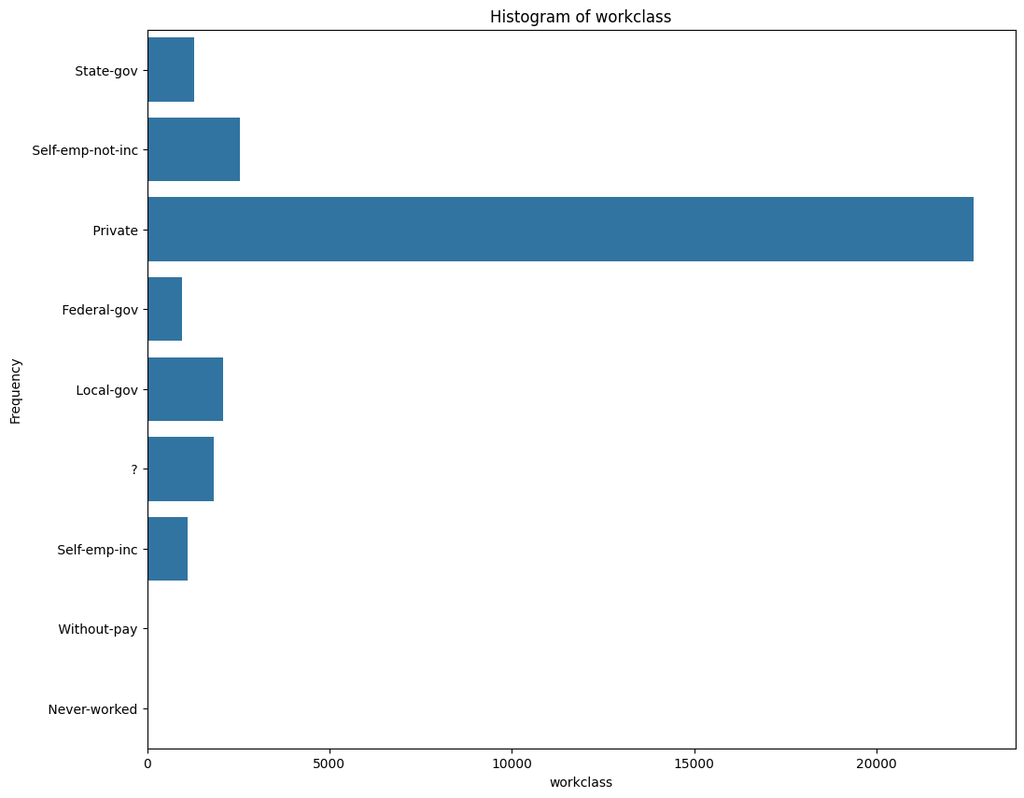

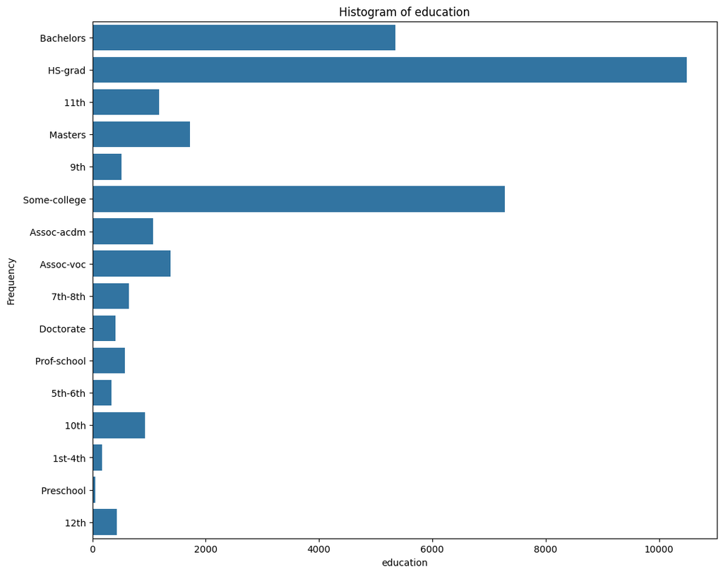

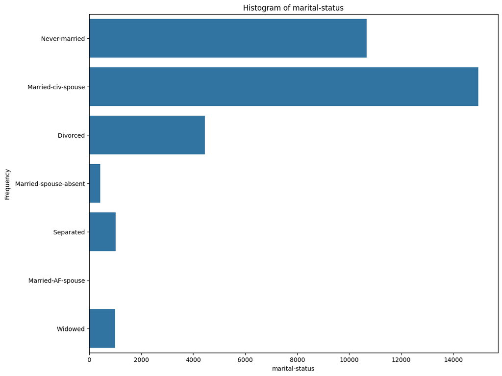

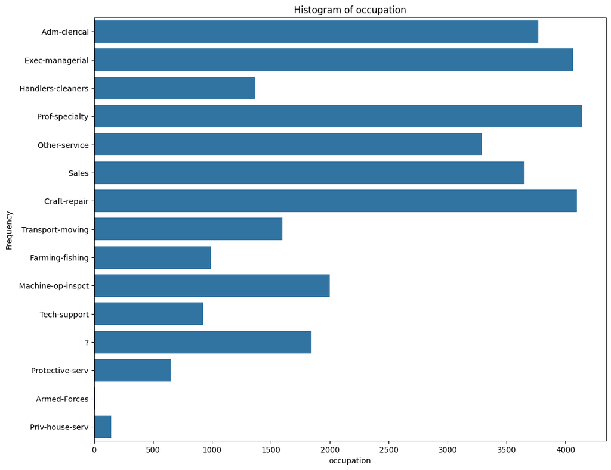

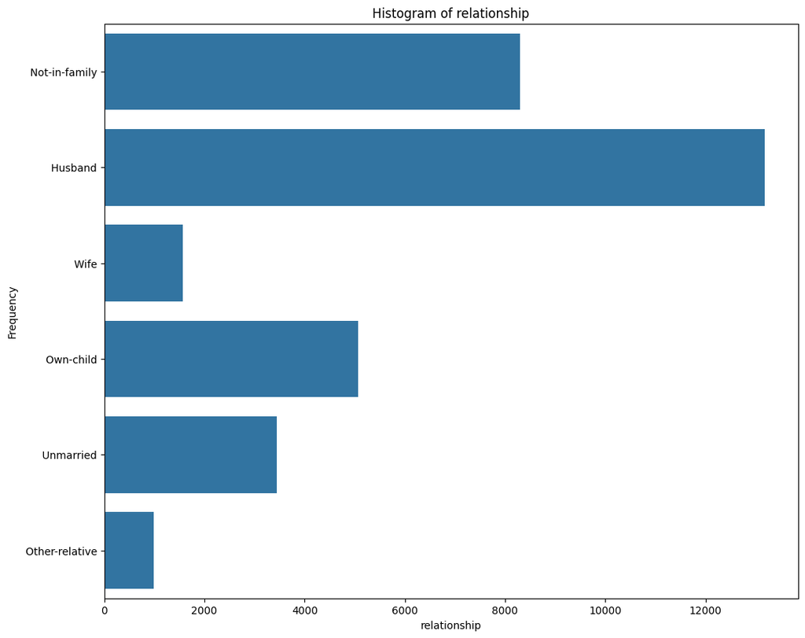

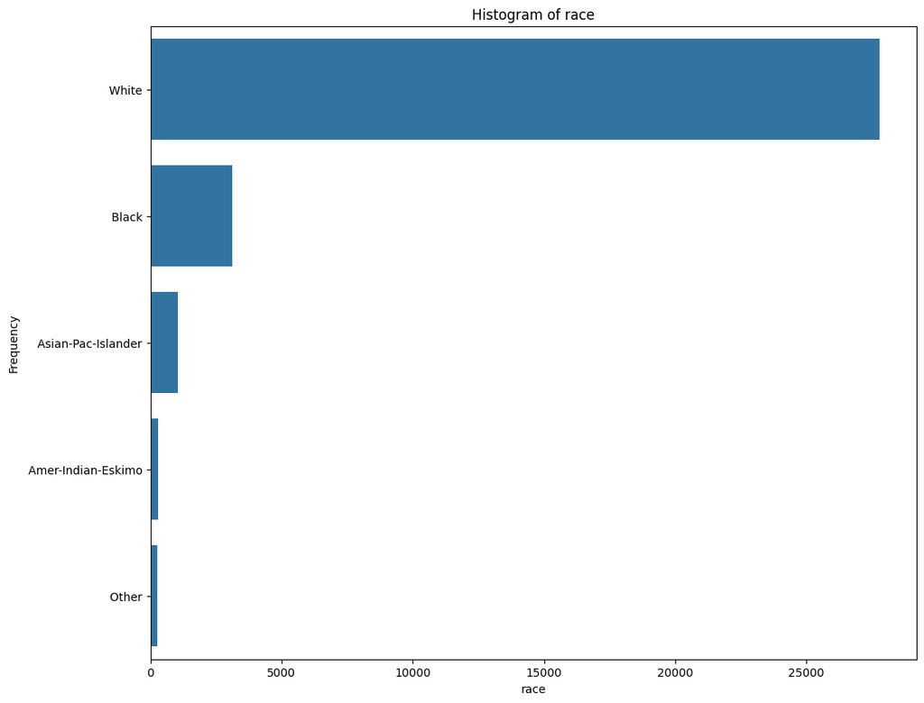

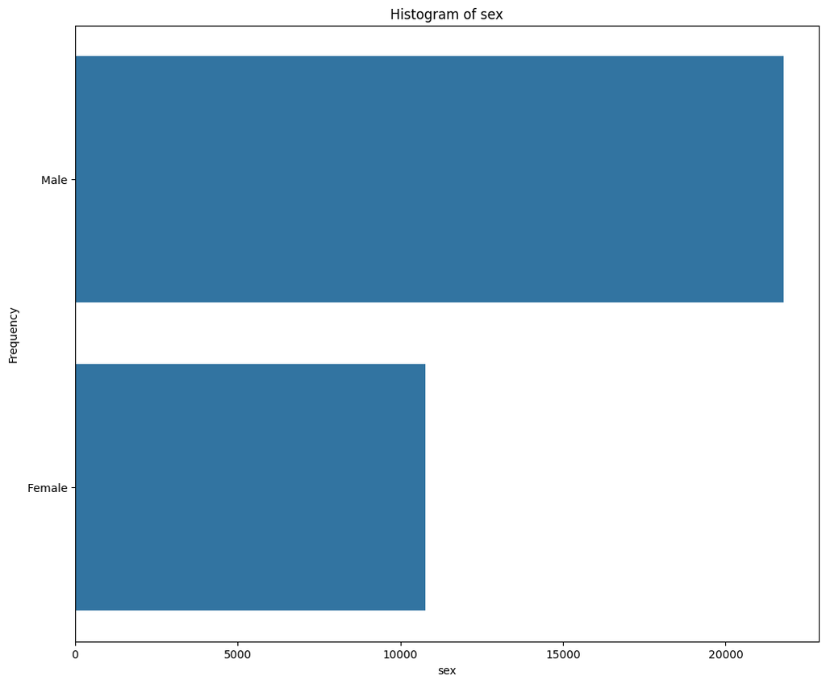

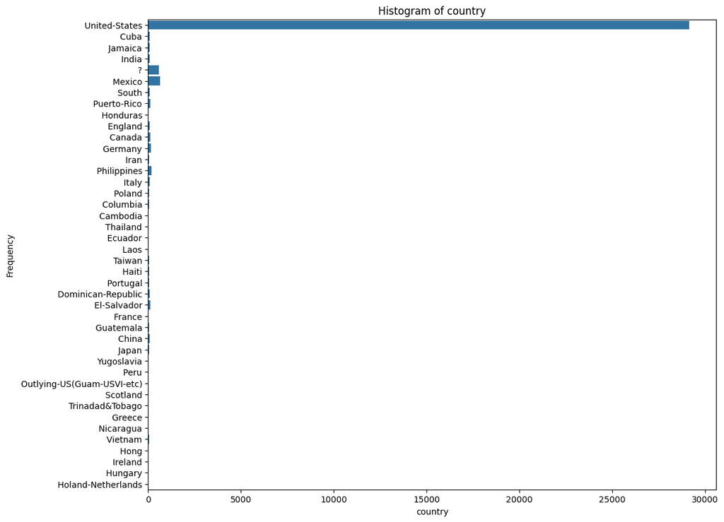

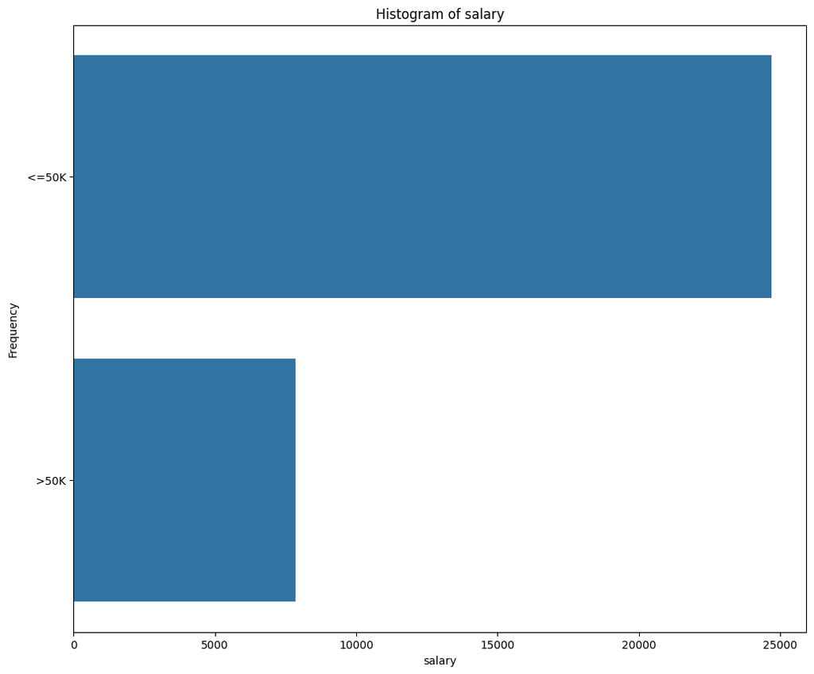

```python
for i in cat_col:
    plt.figure(figsize=(12, 10))
    sns.countplot(df1[i], )
    plt.title(f'Histogram of {i}')
    plt.xlabel(i)
    plt.ylabel('Frequency')
    plt.show()
```

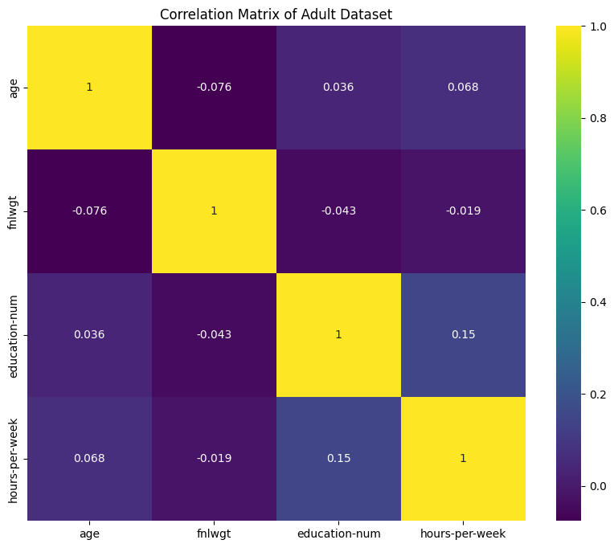

```python
plt.figure(figsize=(10,8))
plt.title("Correlation Matrix of Adult Dataset")
sns.heatmap(num_col.corr(), annot=True, cmap="viridis")
plt.show()
```

- There is no strong coreleations.

## Data preprocessing

```python
# Checking missing values
df1.isna().sum()
```

```
age               0
workclass         0
fnlwgt            0
education         0
education-num     0
marital-status    0
occupation        0
relationship      0
race              0
sex               0
hours-per-week    0
country           0
salary            0
dtype: int64
```

- there is no missing values which is good.

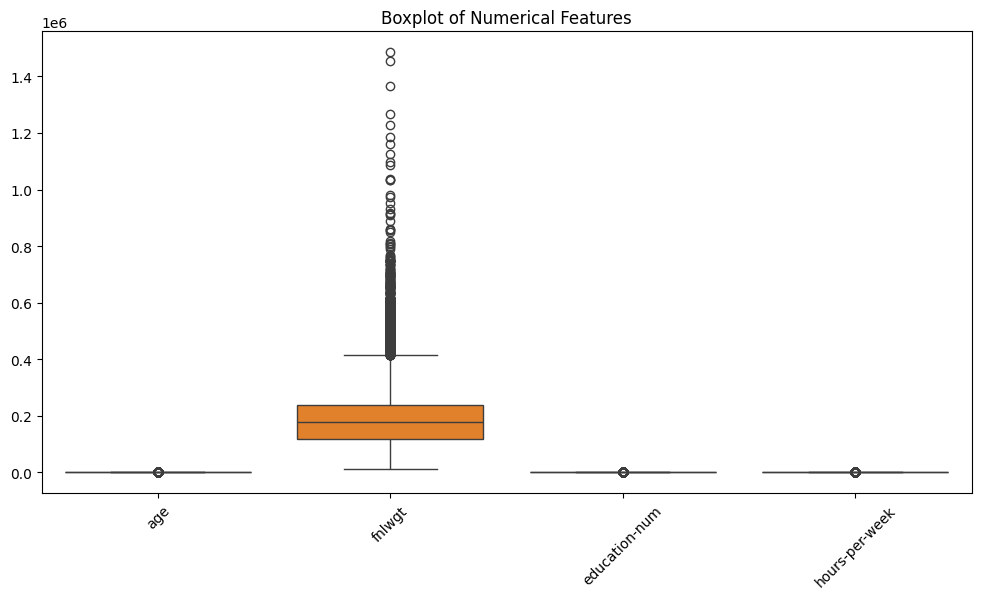

```python
# Plotting box plots for all features
plt.figure(figsize=(12, 6))
sns.boxplot(data=df1)
plt.xticks(rotation=45)
plt.title('Boxplot of Numerical Features')
plt.show()
```

```python
# checking statical summary
df1["fnlwgt"].describe()
```

```
count    3.253500e+04
mean     1.897819e+05
std      1.055595e+05
min      1.228500e+04
25%      1.178215e+05
50%      1.783560e+05
75%      2.369935e+05
max      1.484705e+06
Name: fnlwgt, dtype: float64
```

```python
# Cap outliers
threshold = 0.6
df1['fnlwgt'] = df1['fnlwgt'].clip(upper=df1['fnlwgt'].quantile(1-threshold))
```

```python
# cpying data
df2=df1.copy()
```

- maping the target column::

```python
# we are mapping it
df2["salary"]=df2["salary"].apply(lambda x: 1 if x==" <=50K"  else 0)
df2.salary.value_counts()
```

```
salary
1    24696
0     7839
Name: count, dtype: int64
```

## Prepare for model building

```python
# Separate features (X) and target variable (y)
X = df2.drop("salary", axis=1)
y = df2["salary"]

# Perform one-hot encoding for categorical variables
X = pd.get_dummies(X, drop_first=True)

# Split the data into training, validation, and test sets
X_temp, X_test, y_temp, y_test = train_test_split(X, y, test_size=0.2, random_state=1)
X_train, X_val, y_train, y_val = train_test_split(X_temp, y_temp, test_size=0.2, random_state=1)

# Print the shapes of the resulting datasets
print(X_train.shape, X_val.shape, X_test.shape)
```

```
(20822, 98) (5206, 98) (6507, 98)
```

```python
#define function
def model_performance(model, predictor, target):
  pred = model.predict(predictor)
  acc = accuracy_score(pred, target)
  recall = recall_score(pred, target)
  precision = precision_score(pred, target)
  f1 = f1_score(pred, target)

  # Create a DataFrame
  df_perf = pd.DataFrame({
    "recall": recall,
    "precision": precision,
    "accuracy":acc,
      "f1": f1
  }, index=[0])

  return df_perf
```

```python
# function display confusion matrics
def confusion_matrix_sklearn(model, predictors, target):
    """
    To plot the confusion_matrix with percentages

    model: classifier
    predictors: independent variables
    target: dependent variable
    """
    y_pred = model.predict(predictors)
    cm = confusion_matrix(target, y_pred)
    labels = np.asarray(
        [
            ["{0:0.0f}".format(item) + "\n{0:.2%}".format(item / cm.flatten().sum())]
            for item in cm.flatten()
        ]
    ).reshape(2, 2)

    plt.figure(figsize=(6, 4))
    sns.heatmap(cm, annot=labels, fmt="")
    plt.ylabel("True label")
    plt.xlabel("Predicted label")
```

- **definining which case is important.**
- Both the cases are important as:
  - If we predict a person has a salary <=50K but actually the salary is >50K then a wrong person will be getting the benefits of the scheme and government might lose resources.
  - If we predict a person doesn't have a salary <=50K but actually the salary is <=50K that person will not be able to avail the benefits of the scheme constituting to opportunity loss.